# Tarea 5: intro a clasificación binaria

En este problema evaluamos un clasificador para predecir qué clientes comprararán un seguro para caravanas (*casas móviles* o *campers*). Tenemos cierta información socioeconómica de los clientes, así como información acerca de sus compras y conducta. Este problema es interesante también porque presenta desbalance considerable entre la clase de compra y la de no compra: la mayoría de los clientes no está interesado en este tipo de seguro.

```r
library(tidyverse)
library(tidymodels)
```

Consideremos los siguientes datos (del paquete @ISLR):

The data contains 5822 real customer records. Each record consists of 86 variables, containing sociodemographic data (variables 1-43) and product ownership (variables 44-86). The sociodemographic data is derived from zip codes. All customers living in areas with the same zip code have the same sociodemographic attributes. Variable 86 (Purchase) indicates whether the customer purchased a caravan insurance policy. Further information on the individual variables can be obtained at http://www.liacs.nl/~putten/library/cc2000/data.html

Aquí puedes ver un resumen de las variables, **aunque por el momento no nos preocupamos mucho por esto**:

Todas las variables son numéricas, excepto MOSTYPE, MOSHOOFD

### Variables sociodemográficas y de segmentación (por cliente)

MOSTYPE: Customer Subtype; see L0 MAANTHUI: Number of houses 1 - 10 MGEMOMV: Avg size household 1 - 6 MGEMLEEF: Avg age; see L1 MOSHOOFD: Customer main type; see L2

### Variables sociedemográficas (ligadas a código postal)

MGODRK: Roman catholic MGODPR: Protestant … MGODOV: Other religion MGODGE: No religion MRELGE: Married MRELSA: Living together MRELOV: Other relation MFALLEEN: Singles MFGEKIND: Household without children MFWEKIND: Household with children MOPLHOOG: High level education MOPLMIDD: Medium level education MOPLLAAG: Lower level education MBERHOOG: High status MBERZELF: Entrepreneur MBERBOER: Farmer MBERMIDD: Middle management MBERARBG: Skilled labourers MBERARBO: Unskilled labourers MSKA: Social class A MSKB1: Social class B1 MSKB2: Social class B2 MSKC: Social class C MSKD: Social class D MHHUUR: Rented house MHKOOP: Home owners MAUT1: 1 car MAUT2: 2 cars MAUT0: No car MZFONDS: National Health Service MZPART: Private health insurance MINKM30: Income < 30.000 MINK3045: Income 30-45.000 MINK4575: Income 45-75.000 MINK7512: Income 75-122.000 MINK123M: Income >123.000 MINKGEM: Average income MKOOPKLA: Purchasing power class

### Variables de compra de productos (ligadas al cliente)

PWAPART: Contribution private third party insurance PWABEDR: Contribution third party insurance (firms) … PWALAND: Contribution third party insurane (agriculture) PPERSAUT: Contribution car policies PBESAUT: Contribution delivery van policies PMOTSCO: Contribution motorcycle/scooter policies PVRAAUT: Contribution lorry policies PAANHANG: Contribution trailer policies PTRACTOR: Contribution tractor policies PWERKT: Contribution agricultural machines policies PBROM: Contribution moped policies PLEVEN: Contribution life insurances PPERSONG: Contribution private accident insurance policies PGEZONG: Contribution family accidents insurance policies PWAOREG: Contribution disability insurance policies PBRAND: Contribution fire policies PZEILPL: Contribution surfboard policies PPLEZIER: Contribution boat policies PFIETS: Contribution bicycle policies PINBOED: Contribution property insurance policies PBYSTAND: Contribution social security insurance policies AWAPART: Number of private third party insurance 1 - 12 AWABEDR: Number of third party insurance (firms) … AWALAND: Number of third party insurance (agriculture) APERSAUT: Number of car policies ABESAUT: Number of delivery van policies AMOTSCO: Number of motorcycle/scooter policies AVRAAUT: Number of lorry policies AAANHANG: Number of trailer policies ATRACTOR: Number of tractor policies AWERKT: Number of agricultural machines policies ABROM: Number of moped policies ALEVEN: Number of life insurances APERSONG: Number of private accident insurance policies AGEZONG: Number of family accidents insurance policies AWAOREG: Number of disability insurance policies ABRAND: Number of fire policies AZEILPL: Number of surfboard policies APLEZIER: Number of boat policies AFIETS: Number of bicycle policies AINBOED: Number of property insurance policies ABYSTAND: Number of social security insurance policies

#### Variable respuesta

CARAVAN: Number of mobile home policies 0 - 1

#### Explicaciones de tipo de cliente

L0: Customer subtype

1: High Income, expensive child 2: Very Important Provincials 3: High status seniors 4: Affluent senior apartments 5: Mixed seniors 6: Career and childcare 7: Dinki’s (double income no kids) 8: Middle class families 9: Modern, complete families 10: Stable family 11: Family starters 12: Affluent young families 13: Young all american family 14: Junior cosmopolitan 15: Senior cosmopolitans 16: Students in apartments 17: Fresh masters in the city 18: Single youth 19: Suburban youth 20: Etnically diverse 21: Young urban have-nots 22: Mixed apartment dwellers 23: Young and rising 24: Young, low educated 25: Young seniors in the city 26: Own home elderly 27: Seniors in apartments 28: Residential elderly 29: Porchless seniors: no front yard 30: Religious elderly singles 31: Low income catholics 32: Mixed seniors 33: Lower class large families 34: Large family, employed child 35: Village families 36: Couples with teens ‘Married with children’ 37: Mixed small town dwellers 38: Traditional families 39: Large religous families 40: Large family farms 41: Mixed rurals

L2: customer main type keys:

1: Successful hedonists 2: Driven Growers 3: Average Family 4: Career Loners 5: Living well 6: Cruising Seniors 7: Retired and Religeous 8: Family with grown ups 9: Conservative families 10: Farmers

### Lectura, partición y exploración de datos

Queremos predecir la variable *Purchase*, que indica si el cliente compró o no el seguro de camper. La separación la hacemos de forma que tengamos misma proporción de compras en cada conjunto:

```r
caravan <- read_csv("./datos/caravan.csv", show_col_types = FALSE) |>
  mutate(MOSTYPE = factor(MOSTYPE),
         MOSHOOFD = factor(MOSHOOFD))
set.seed(823)
# usamos muestreo estratificado para tener el mismo balance
# de Purchase en entrenamiento y prueba
caravan_split = initial_split(caravan, strata = Purchase, prop = 0.7)
caravan_split
```

```
<Training/Testing/Total>
<4075/1747/5822>
```

```r
caravan_ent <- training(caravan_split)
```

Y vemos el desbalance de clases:

```r
nrow(caravan_ent)
```

```
[1] 4075
```

```r
caravan_ent |> count(Purchase) |>
  mutate(pct = 100 * n / sum(n)) |>
  mutate(pct = round(pct, 2))
```

```
# A tibble: 2 × 3
  Purchase     n   pct
  <chr>    <int> <dbl>
1 No        3827 93.9
2 Yes        248  6.09
```

Esta es la distribución natural de respuesta que vemos en los datos, y tenemos relativamente pocos datos en la categoría “Yes”.

**Pregunta 1**: ¿Crees que una tasa de predicción de clase correcta (Si o No compra) de alrededor de 92% sería buena para este problema? ¿Qué tasa de correctos tendrías si tu predicción es la predicción trivial “No compra”?

Depende de qué metrica estemos considerando para evaluar. Si se considera un $92\%$ de predicciones correctas sin importar la clase, es una tasa muy buena, sin embargo si consideramos la tasa de predicción para cada clase individual, posiblemente veamos que tenemos muchos aciertos para la clase “No compra” y muy pocos para la clase “compra”.

### Regresión logística regularizada

Usaremos regresión logística regularizada (veremos más en la próxima clase, por el momento considera que este método produce para cada caso probabilidad de que un cliente particular compre la póliza).

```r
# preparacion de datos
caravan_receta <- recipe(Purchase ~ . , caravan_ent) |>
  # convertir a dummy variables nominales, esto lo explicamos
  # con detalle más adelante
  step_dummy(all_nominal(), -Purchase) |>
  step_relevel(Purchase,  ref_level = "Yes", skip = TRUE)

modelo_logistico <-
  logistic_reg(mixture = tune(), penalty = tune()) |>
  set_args(lambda.min_ratio = 0) |>
  set_engine("glmnet")
flujo_caravan <- workflow() |>
  add_recipe(caravan_receta) |>
  add_model(modelo_logistico)
```

```r
# configurar partición
val_split <- manual_rset(caravan_split |> list(), "validación")
# hacemos un grid de valores de mezcla y penalización
params <- parameters(penalty(range = c(-5, 2), trans = log10_trans()),
                            mixture(range = c(0, 1)))
grid <- grid_regular(params, levels = c(penalty = 15, mixture = 4))
```

Y ahora ajustamos todos los modelos. Evaluamos con la pérdida logarítmica:

```r
mis_metricas <- metric_set(mn_log_loss)
eval_tbl <- tune_grid(flujo_caravan,
                      resamples = val_split,
                      grid = grid,
                      metrics = mis_metricas)
ajustes_tbl <- eval_tbl |>
  unnest(cols = c(.metrics)) |>
  select(id, mixture, penalty, .metric, .estimate)
ajustes_tbl
```

```
# A tibble: 60 × 5
   id         mixture   penalty .metric     .estimate
   <chr>        <dbl>     <dbl> <chr>           <dbl>
 1 validación       0 0.00001   mn_log_loss     0.204
 2 validación       0 0.0000316 mn_log_loss     0.204
 3 validación       0 0.0001    mn_log_loss     0.204
 4 validación       0 0.000316  mn_log_loss     0.204
 5 validación       0 0.001     mn_log_loss     0.204
 6 validación       0 0.00316   mn_log_loss     0.204
 7 validación       0 0.01      mn_log_loss     0.201
 8 validación       0 0.0316    mn_log_loss     0.199
 9 validación       0 0.1       mn_log_loss     0.199
10 validación       0 0.316     mn_log_loss     0.204
# … with 50 more rows
# ℹ Use `print(n = ...)` to see more rows
```

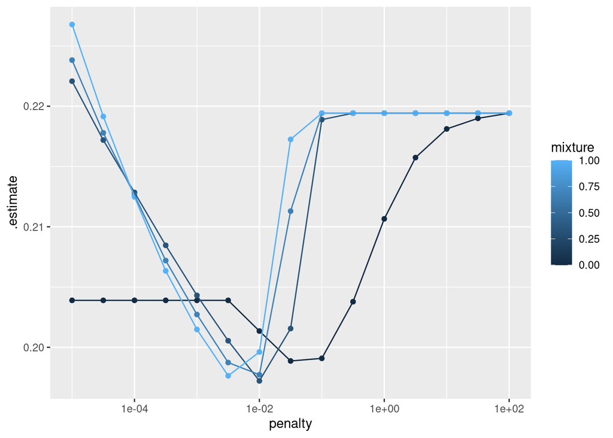

```r
ggplot(ajustes_tbl, aes(x = penalty, y = .estimate, colour = mixture, group = mixture)) +
  geom_point() + geom_line() + scale_x_log10()
```

Finalmente, seleccionamos el mejor modelo:

```r
mejor_modelo <- select_best(eval_tbl)
mejor_modelo
```

```
# A tibble: 1 × 3
  penalty mixture .config
    <dbl>   <dbl> <chr>
1    0.01   0.333 Preprocessor1_Model22
```

```r
modelo_final <- finalize_workflow(flujo_caravan, mejor_modelo) |>
  fit(caravan_ent)
```

### Análisis de las probabilidades de compra

```r
caravan_prueba <- testing(caravan_split)
pred_probas <- predict(modelo_final, caravan_prueba, type="prob")
head(pred_probas)
```

```
# A tibble: 6 × 2
  .pred_Yes .pred_No
      <dbl>    <dbl>
1   0.0348     0.965
2   0.0336     0.966
3   0.0353     0.965
4   0.00901    0.991
5   0.0442     0.956
6   0.0210     0.979
```

```r
pred_probas <- pred_probas |>
  bind_cols(caravan_prueba)
head(pred_probas |> select(.pred_Yes, .pred_No, Purchase))
```

```
# A tibble: 6 × 3
  .pred_Yes .pred_No Purchase
      <dbl>    <dbl> <chr>
1   0.0348     0.965 No
2   0.0336     0.966 No
3   0.0353     0.965 No
4   0.00901    0.991 No
5   0.0442     0.956 No
6   0.0210     0.979 No
```

Examinamos las probabilidades de compra para la muestra de prueba:

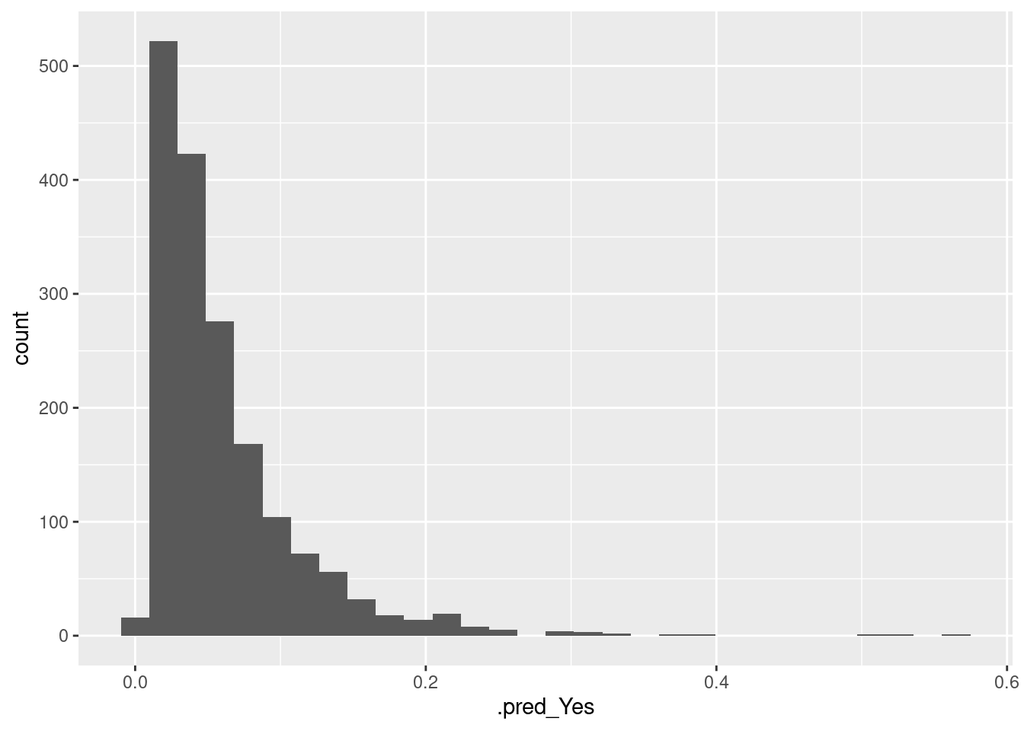

```r
ggplot(pred_probas, aes(x = .pred_Yes)) + geom_histogram()
```

**Pregunta 2**: ¿Qué pasaría con estos datos si pones un punto de corte de probabilidad 0.5 para clasificar a alguien como candidato a comprar un seguro de casa móvil? Por ejemplo, si queremos clasificar a la clase de máxima probabilidad hacemos:

```r
clase_probas_0.5 <- predict(modelo_final, caravan_prueba)
clase_probas_0.5 |> group_by(.pred_class) |> count()
```

```
# A tibble: 2 × 2
# Groups:   .pred_class [2]
  .pred_class     n
  <fct>       <int>
1 Yes             3
2 No           1744
```

**¿Cuántos candidatos a comprar obtendrías?¿Tiene sentido que con estos datos encuentres probabilidades muy grandes de que alguien compre este seguro?**

Tenemos únicamente 3 predicciones de candidatos a comprar, mientras que tenemos 1744 candidatos a no hacerlo.

#### Probando puntos de corte

Podemos por ejemplo considerar como candidatos a aquellos clientes que tengan probabilidad mayor a 0.10 de ser compradores del seguro:

```r
pred_probas <- pred_probas |>
  mutate(tipo = ifelse(.pred_Yes > 0.10, "candidato", "no_candidato"))
```

Ahora en la muestra de prueba podemos cruzar nuestra clasificación con el verdadero valor:

```r
tabla_confusion <- pred_probas |>  group_by(tipo, Purchase) |>
  count()
tabla_confusion |> pivot_wider(names_from = Purchase, values_from = n)
```

```
# A tibble: 2 × 3
# Groups:   tipo [2]
  tipo            No   Yes
  <chr>        <int> <int>
1 candidato      228    46
2 no_candidato  1419    54
```

**Pregunta 3**: ¿cuántos candidatos encontraste? ¿Qué porcentaje de la muestra total representa este número? ¿Entre estos que candidatos encontraste, qué porcentaje realmente es compradorde este seguro? (este último número se llama *precisión*).

Se encontraron 274 candidatos totales, lo que equivale a $15.68\%$ de la muestra total.

El porcentaje de candidatos que realmente son compradores de los seguros es de $46/(228+46) \approx 16.79\%$

Si escoges al azar de la muestra de prueba el mismo número de candidatos, ¿qué porcentaje de compradores esperas encontrar en este grupo escogido al azar? Compara esto con lo que obtuviste usando el modelo. ¿Qué tan superior es tu modelo en escoger comparado con escoger clientes al azar para intentar venderles el seguro?

```r
set.seed(8)
counts <- sample_n(caravan_prueba, size=274) |>
  group_by(Purchase) |> count() |>
  pivot_wider(names_from = Purchase, values_from = n)
print(paste0("Proporcion No: ", counts$No / sum(counts)))
```

```
[1] "Proporcion No: 0.945255474452555"
```

```r
print(paste0("Proporcion Si: ", counts$Yes / sum(counts)))
```

```
[1] "Proporcion Si: 0.0547445255474453"
```

```r
print(paste0("Cantidad de posibles compradores: ", counts$Yes))
```

```
[1] "Cantidad de posibles compradores: 15"
```

Al escoger al azar esperamos encontrar un porcentaje cercano a la proporción correspondiente a los candidatos para comprar el seguro, que es aproximadamente del $6\%$.

El modelo encuentra más candidatos a comprar el seguro, pero se equivoca muchísimo.

**Pregunta 4**: De todos los compradores verdaderos en la muestra de prueba, qué porcentaje clasificaste como candidatos? (Este número se llama *cobertura, sensibilidad* o *recall*). ¿Qué porcentaje se te “escapó”? ¿Qué significa este número en términos de, por ejemplo, una campaña de ventas centrada en los candidatos que produjimos con el modelo?

De todos los compradores verdaderos, se clasificaron correctamente $46\%$. Se escaparon $54\%$ de posibles compradores.

Este modelo es un mal clasificador ya que no estamos capturando ni la mitad de todos los posibles compradores ni con el corte realizado, por lo que posiblemente la campaña no tenga el alcance esperado ya que estaremos considerando también a personas no potenciales en compra.

#### Probando otros punto de corte

Arriba cortamos en 0.10, pero para nuestro problema puede ser que otro punto de corte sea mejor.

**Pregunta 5** ¿Si subimos el punto de corte (somos más exigentes), qué esperaríamos que pasara con número de clasificados como candidatos, cobertura y precisión? ¿Qué pasa si bajamos el punto de corte?

```r
pred_probas <- pred_probas |>
  mutate(tipo = ifelse(.pred_Yes > 0.3, "candidato", "no_candidato"))

tabla_confusion <- pred_probas |>  group_by(tipo, Purchase) |>
  count()
tabla_confusion |> pivot_wider(names_from = Purchase, values_from = n)
```

```
# A tibble: 2 × 3
# Groups:   tipo [2]
  tipo            No   Yes
  <chr>        <int> <int>
1 candidato        7     3
2 no_candidato  1640    97
```

Esperaríamos que conforme aumentamos el punto de corte disminuya la cantidad de usuarios clasificados como sí candidatos ya que somos menos tolerantes a los errores, por lo que también aumentaría la precisión, sin embargo disminuye el recall.

Puedes probar distintos punto de corte y presentarlos en la siguiente gráfica (pero hay muchas otras que veremos en clase). En este caso, ordenamos los datos de mayor probabilidad a menor. Esto quiere decir que el primer candidato que escogeríamos es el de mayor probabilidad. Ahora vamos bajando en la tabla, y tomamos como candidatos a todos los que estén por arriba de cada renglón. Calculamos la cobertura (de todos los positivos qué porcentaje hemos capturado)

```r
curva_ganancia <- gain_curve(pred_probas, truth = factor(Purchase), .pred_Yes,
                           event_level = "second")
curva_ganancia
```

```
# A tibble: 1,654 × 4
      .n .n_events .percent_tested .percent_found
   <dbl>     <dbl>           <dbl>          <dbl>
 1     0         0          0                   0
 2     1         0          0.0572              0
 3     2         0          0.114               0
 4     3         1          0.172               1
 5     4         2          0.229               2
 6     5         2          0.286               2
 7     6         2          0.343               2
 8     7         2          0.401               2
 9     8         3          0.458               3
10     9         3          0.515               3
# … with 1,644 more rows
# ℹ Use `print(n = ...)` to see more rows
```

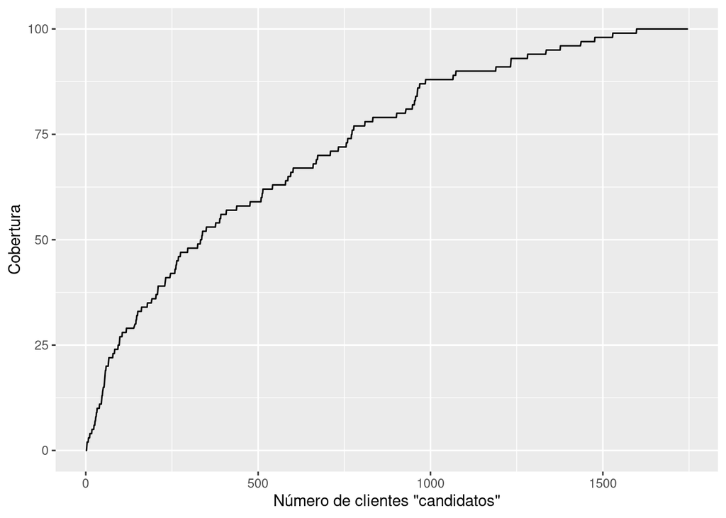

```r
ggplot(curva_ganancia,
       aes(x = .n, y = .percent_found)) +
  geom_path() +
  xlab("Número de clientes \"candidatos\"") +
  ylab("Cobertura")
```

**Pregunta 7**: (más difícil) En esta cruva, ¿qué puntos corresponden a puntos de corte de probabilidad más alta y más baja? Si quisieras capturar al 60% de los verdaderos compradores, ¿cuántos candidatos tienes que tomar? ¿Qué punto de corte de probablidad se puede usar? Puedes usar la siguiente tabla para contestar la segunda pregunta:

```r
total_compradores <- pred_probas |> summarise(total_compradores = sum(Purchase == "Yes")) |>
  pull(total_compradores)
pred_probas |> select(.pred_Yes, Purchase) |>
  arrange(desc(.pred_Yes)) |>
  mutate(num_compradores = cumsum(Purchase == "Yes")) |>
  mutate(cobertura =  num_compradores / total_compradores )
```

```
# A tibble: 1,747 × 4
   .pred_Yes Purchase num_compradores cobertura
       <dbl> <chr>              <int>     <dbl>
 1     0.571 No                     0      0
 2     0.527 No                     0      0
 3     0.505 Yes                    1      0.01
 4     0.385 Yes                    2      0.02
 5     0.367 No                     2      0.02
 6     0.338 No                     2      0.02
 7     0.325 No                     2      0.02
 8     0.311 Yes                    3      0.03
 9     0.303 No                     3      0.03
10     0.303 No                     3      0.03
# … with 1,737 more rows
# ℹ Use `print(n = ...)` to see more rows
```

El punto de corte de probabilidad más alta está en el inferior de la gráfica, ya que con un punto de corte con una probabilidad alta, tenemos una cobertura de 0 clientes.

El punto de corte de probabilidad más baja está en la parte superior de la gráfica, pues si consideramos con una probabilidad cercana a 0 que son compradores estaríamos alcanzando a todos los compradores posibles.

Deberíamos tomar al rededor de 500 clientes para capturar al $60\%$ de los posibles compradores, y esto de lograría con un punto de corte en probabilidad de $6.8\%$.

**Pregunta 8** (opcional) Piensa en qué circunstancias de toma de decisiones este tipo de curva es buen insumo que explica el desempeño del modelo, y cómo debe utilizarse para tomar esas decisiones.